# Why R?

## R is for Reproducibility

**Why R?**

- Programming language for data analysis
- Free!
- Open source
- Widely used and supported across all disciplines
- Can be used on Windows, Mac OS X or Linux

Show the learners a screen shot of R running from the terminal. Perhaps show that it is an overgrown calculator:

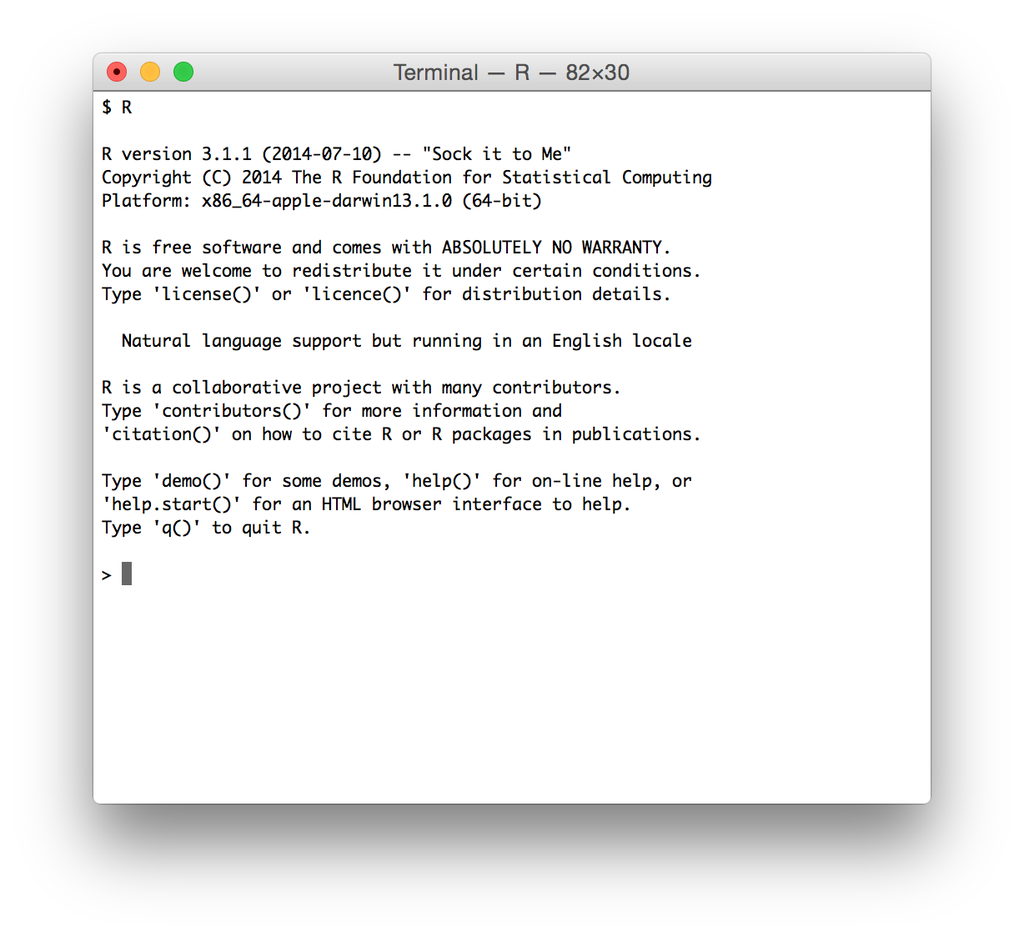

**Why not language X?**

- There are a number of other great programming tools out there that can also be used to improve the reproducibility of your analysis
- The key is to use some type of language that will allow you to automate and document your analysis
- Once you master one language you’ll probably find it easier to learn another
- Might ask learners what programming languages they already know with a show of hands for…
- R
- Python
- Perl
- SQL
- Java
- C/C++
- It would be good to jot down numbers to store as “data” for later usage.

**You could just type into the command prompt…**

- … but that doesn’t help much with documentation
- … but that doesn’t help much with automation

**A better solution**

With RStudio you can combine your programming and your documentation

- RStudio gives you a single environment to combine your documentation and your analysis
- It runs on top of R
- Gives you a bunch of really cool features that we’ll explore throughout the workshop
- Show the learners a screen shot of RStudio and review the panes

[figure not shown]